# National Storm Analysis - Most Harmful Events Impacting Population/Economic Health

Author: Philip Wong

Date: 2022-03-19

### Project Requirements & Synopsis:

“The basic goal of this assignment is to explore the NOAA Storm Database and answer some basic questions about severe weather events. You must use the database to answer the questions below and show the code for your entire analysis. Your analysis can consist of tables, figures, or other summaries. You may use any R package you want to support your analysis.”

This report is structured based on the following topics:  
- Data Processing (importing data)  
- Data Exploration (managing null values)  
- Data Analysis [1] Which types of events are most harmful with respect to population health?  
- Data Analysis [2] Which types of events have the greatest economic consequences?

### Data Processesing & Exploration

```r
# import libraries
library(tidyverse)
library(knitr)
library(scales)
# import data
df <- read_csv("input/repdata_data_StormData.csv")
# How many duplicate values for each variable?
colSums(is.na(df))
```

```
##    STATE__   BGN_DATE   BGN_TIME  TIME_ZONE     COUNTY COUNTYNAME      STATE
##          0          0          0          0          0       1589          0
##     EVTYPE  BGN_RANGE    BGN_AZI BGN_LOCATI   END_DATE   END_TIME COUNTY_END
##          0          0     547332     287743     243411     238978          0
## COUNTYENDN  END_RANGE    END_AZI END_LOCATI     LENGTH      WIDTH          F
##     902297          0     724837     499225          0          0     843563
##        MAG FATALITIES   INJURIES    PROPDMG PROPDMGEXP    CROPDMG CROPDMGEXP
##          0          0          0          0     465934          0     618413
##        WFO STATEOFFIC  ZONENAMES   LATITUDE  LONGITUDE LATITUDE_E LONGITUDE_
##     142069     248769     800017         47          0         40          0
##    REMARKS     REFNUM
##     311737          0
```

### Data Analysis

##### Across the United States, which types of events (as indicated in the EVTYPE variable) are most harmful with respect to population health?

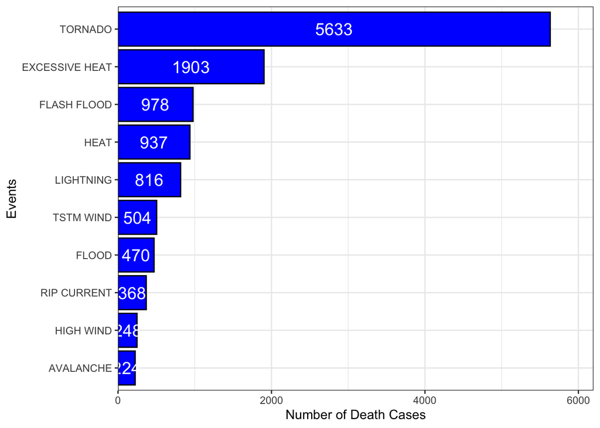

```r
# population health - based on number of fatalities
df %>% group_by(EVTYPE) %>%
   summarise(Total_Deaths = sum(FATALITIES)) %>%
   ungroup() %>%
   arrange(desc(Total_Deaths)) %>%
   head(10) %>%
   ggplot(aes(x = reorder(EVTYPE, Total_Deaths), y = Total_Deaths)) +
   geom_bar(stat = 'identity', color = 'black', fill = 'blue') +
   coord_flip() +
   labs(x = "Events", y = "Number of Death Cases") +
   theme_bw() +
   scale_y_continuous(expand = expansion(mult = c(0, .1))) +
   geom_text(aes(label = Total_Deaths), position = position_stack(vjust = 0.5), size = 5, color = 'white')
```

Result: It appears that tornados are the most harmful with respect to population health (# of death cases).

##### Across the United States, which types of events have the greatest economic consequences?

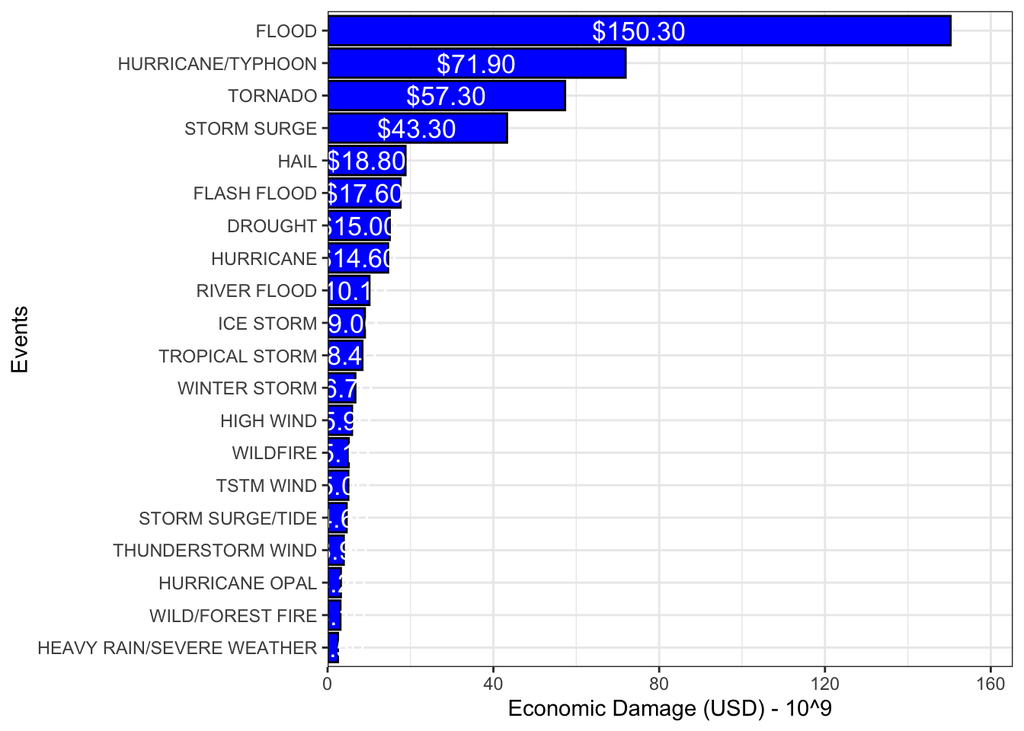

```r
# replace any null values to 0
df$PROPDMG[is.na(df$PROPDMG)] <- 0
df$PROPDMGEXP[is.na(df$PROPDMGEXP)] <- 0
df$CROPDMG[is.na(df$CROPDMG)] <- 0
df$CROPDMGEXP[is.na(df$CROPDMGEXP)] <- 0

# convert property & cropt damage into numbers based on the following aggregations = H = 10^2, K=10^3, M =10^6, and B=10^9.
df2 <- df %>%
  mutate(
    PROP_DAMAGE = case_when(
      PROPDMGEXP == 'H' ~ PROPDMG * 10^2,
      PROPDMGEXP == 'K' ~ PROPDMG * 10^3,
      PROPDMGEXP == 'M' ~ PROPDMG * 10^6,
      PROPDMGEXP == 'B' ~ PROPDMG * 10^9,
      TRUE ~ 0
    )
  ) %>%
  mutate(
    CROP_DAMAGE = case_when(
      CROPDMGEXP == 'H' ~ CROPDMG * 10^2,
      CROPDMGEXP == 'K' ~ CROPDMG * 10^3,
      CROPDMGEXP == 'M' ~ CROPDMG * 10^6,
      CROPDMGEXP == 'B' ~ CROPDMG * 10^9,
      TRUE ~ 0
    )
  )

# aggregate the newly added variables - creating a single variable
df2 %>%
  mutate(Total_Damage = PROP_DAMAGE + CROP_DAMAGE) %>%
  group_by(EVTYPE) %>%
  summarise(Economic_Damage = round(sum(Total_Damage)/10^9,1)) %>%
  ungroup() %>%
  arrange(desc(Economic_Damage)) %>%
  head(20) %>%
  ggplot(aes(x = reorder(EVTYPE, Economic_Damage), y = Economic_Damage)) +
  geom_bar(stat = 'identity', color = 'black', fill = 'blue') +
  coord_flip() +
  labs(x = "Events", y = "Economic Damage (USD) - 10^9") +
  theme_bw() +
  scale_y_continuous(expand = expansion(mult = c(0, .1))) +
  geom_text(aes(label = dollar_format()(Economic_Damage)), position = position_stack(vjust = 0.5), size = 4.5, color = 'white')
```

Result: Floods causes the greatest economic damage/consequence.